# Tidyverse Curie

Enora LAAS

26 septembre 2017

# Installation du package Tidyverse (et ses “sous-packages”)

```r
library("tidyverse")
#library("readr") ##ouverture du csv en format tibble
#library("tibble")  ##conversion des objets en tibble
#library("dplyr")  ##manipulation des données
#library("tidyr")  ##manipulation des dataframe
library("stringr") ##
#library("ggplot2")  ###figures
#library("purrr")  ##gestion des listes
library("broom")  ##récupération des statistiques
```

# Chargement des data en format “tibble” : package “readr”

Ouvre un csv de façon “friendly”

Ouvre le fichier et specifie le format de chaque variable.

```r
mtcars<-read_csv(readr_example("mtcars.csv"))
source("importation neorep.R")
curie <- as_tibble(curie)
```

# Tibble

```r
print(curie, n =10)
```

```
## # A tibble: 1,199 x 136
##       datexam  tuicc tclin  nuicc     datdeb typana typanac   chir
##        <date> <fctr> <int> <fctr>     <date> <fctr>  <fctr> <fctr>
##  1 2007-11-15      2    20      0 2007-11-15      1              1
##  2 2006-05-24      2    40      0 2006-05-31      1              1
##  3 2006-05-02      2    30      2 2006-04-14      1              1
##  4 2006-12-21      2    45      0 2006-12-27      1              1
##  5 2006-03-29      2    50      0 2006-04-07      1              1
##  6 2005-12-22      2    40      1 2005-12-29      1              1
##  7 2009-08-18      1    15      0 2008-08-18      1              1
##  8 2010-11-29      2    50      1 2010-12-06      1              1
##  9 2010-11-12      2    30      1 2010-11-15      1              1
## 10 2010-12-06      3    55      1 2010-12-06      1              1
## # ... with 1,189 more rows, and 128 more variables: datchir <date>,
## #   typchir <fctr>, plachir <fctr>, typax <fctr>, ggprel <int>,
## #   ggenv <int>, ggfib <int>, marges <fctr>, enva <fctr>, sain <int>,
## #   tailh <int>, tailp <int>, rth <fctr>, rtdeb <date>, rtfin <date>,
## #   hormo <fctr>, dathor <date>, typhor <fctr>, finhor <date>,
## #   adjdebc <date>, adjfin.q1 <date>, adjfin.q2 <date>, adjnbc <int>,
## #   adjarc <fctr>, adjaraut <fctr>, adjch <fctr>, adjfinc <date>,
## #   adjar.q1 <fctr>, adjar.q2 <fctr>, adjarcl <fctr>, heradj <fctr>,
## #   debher <date>, finher <date>, dader <date>, etader <fctr>,
## #   etaviv <fctr>, causdc <fctr>, datcion <date>, rec <fctr>,
## #   datmet.f1 <date>, met <fctr>, met.1 <fctr>, delmet <time>,
## #   delmet2 <time>, RCH4.f <fctr>, tuicc.c.f <fctr>, tuicc2.c.f <fctr>,
## #   tclin.c.f <fctr>, N <dbl>, N.f <fctr>, Ninit.f <fctr>, cAJCC <chr>,
## #   bmi <dbl>, typana.c.f <fctr>, RH.f <fctr>, subtype.f <fctr>,
## #   typneo.f <fctr>, typchir.c.f <fctr>, typchirgang.f <fctr>,
## #   ggenv0.f <fctr>, neobioscore_c_stage <dbl>, neobioscore_p_stage <dbl>,
## #   neobioscore_ER <dbl>, neobioscore_HER2 <dbl>, neobioscore_grade <dbl>,
## #   grade_nucleaire <fctr>, neobioscore_grade_nucl <dbl>, CPS <fctr>,
## #   neobioscore_grade_EE <fctr>, CPS_EG_grade_EE <fctr>,
## #   neobioscore_grade_nucleaire <fctr>, CPS_EG_grade_nucleaire <fctr>,
## #   DFS <dbl>, RCB <dbl>, RCB_class_2 <fctr>, embols_sein <fctr>,
## #   embols_sein_with_NA_pCR_imputed_as_no <fctr>, id <int>,
## #   Her_groupe <fctr>, BMI <dbl>, BMI_cl <fctr>, age <dbl>, age_cl <fctr>,
## #   taille_cl <fctr>, HR <fctr>, Luminal <fctr>, BL <fctr>, ggl <fctr>,
## #   groupe <fctr>, Node_preop <fctr>, T_preop <fctr>, histo <fctr>,
## #   Gd <fctr>, tailh_cl <fctr>, Node_postop <fctr>, Grade <fctr>,
## #   Size <fctr>, Histology <fctr>, Menopausal <fctr>, surgery <fctr>, ...
```

autorise les listes, les matrices…comme valeur de cellule as_tibble()

*la structure de la variable est donnée entre parenthèses sous chaque nom de variable

*des informations concernant le jeu de données, notamment ses dimensions (Source: local data frame), sont affichées dans la partie supérieure de l’affichage

*seules les variables qui peuvent être entièrement affichées dans la fenêtre sont visibles

*ET seules les premières lignes sont affichées.

Si on veut voir plus :

o **options(tibble.print_max = n, tibble.print_min = m)**: if there are more than nrows, print only the first m rows. Use options(tibble.print_max = Inf) to always show all rows.

o **options(tibble.width = Inf)** will always print all columns, regardless of the width of the screen.

# Dplyr

## **select()** : selectionner des colonnes

**Select (d, var1, var2,…)** : permet de selectionner des colonnes

```r
curie[,c("rtdeb","rtfin")]
# est équivalent à :
select(curie, rtdeb,rtfin) ##pas besoin de ""
select(curie, hormo:finhor)##selection de plusieurs colonnes contiguëes avec ":"
select(curie, -BMI, -age) ##anti selection par nom de variables
select(curie, -starts_with("neobio"))
select(curie, starts_with("adj", ignore.case=TRUE))
select(curie, ends_with("her"))
select(curie, -contains("q1"))
select(curie, matches("uicc"))
```

# **filter()** : filtrer les lignes

Permet de filtrer les lignes du jeu de données qui satisfont un critère. Son écriture est très proche de la fonction **subset** :

```r
filter(curie, datchir > "2010-01-01")

# avec plusieurs critères :
#ces 2 écritures sont identiques :
filter(curie, groupe =="luminal" & datchir > "2010-01-01")
filter(curie, groupe =="luminal", datchir > "2010-01-01")

# le symbole | s'utilise comme en base :
filter(curie, groupe =="luminal" | groupe =="her2+")
```

# **arrange()**

Trie le jeu de données, dans l’ordre croissant ou décroissant selon un ou plusieurs critères. Les données manquantes sont reléguées en fin de tableau.

```r
arrange(curie, datexam) ##ordre croissant par defaut
arrange(curie, desc(datexam)) ##par ordre decroissant
```

# **mutate()**

Permet la transformation d’une variable existante ou la création d’une nouvelle variable dans le jeu de données.

mutate(data, nouvelle_var = …)

```r
levels(curie$typax) #1 GS, 2 CA, 3 les 2
```

```
## [1] "1" "2" "3"
```

```r
curie <- mutate(curie,
    chirggl=as.factor(ifelse(typax == 2 | typax ==3, "CA", "GS")))

summary(curie$chirggl)
```

```
##   CA   GS NA's
## 1169   27    3
```

*mutate* = fonction dite “window” : l’opération qui est réalisée sur la variable restitue une variable de même taille. C’est une transformation

# **summarise()**

**summarize** (ou **summarise**) = fonction dite de “résumé”. À l’inverse de **mutate**, quand une fonction **summarize** est appelée, elle retourne une seule information (ex: moyenne, variance, effectif… )

Le résultat d’une fonction **summarise** est un *tbl_df* à autant de colonnes que de variables calculées.

```r
summarise(curie, gg_moy=mean(ggenv, na.rm=T))
```

```
##     gg_moy
## 1 1.432749
```

```r
#calcul de plusieurs indicateurs à la fois avec ","
summarise(curie,
          gg_moy=mean(ggenv, na.rm=T),
          gg_et = sd(ggenv, na.rm=T))
```

```
##     gg_moy   gg_et
## 1 1.432749 2.54423
```

# Enchaîner les opérations de manipulation des données et faire les calculs par groupes :

## pipe operator %>% ( *{magrittr}*)

Evite l’imbrication des fonctions les unes dans les autres

**%>%** peut être lu comme « ensuite » ou « puis ».

L’opérateur **%>%** passe comme premier argument à la fonction qu’on trouve immédiatement à sa droite, ce qui se trouve à sa gauche.

Si on souhaite passer à droite du pipe un argument qui n’est pas en première position dans la fonction que l’on souhaite utiliser, on utilise “.”

# **group_by()**

Découpe un jeu de données pour réaliser des opérations sur chacun des sous-ensembles.

Dans un pipe, dès lors qu’un **group_by** est introduit, toutes les opérations qui suivent sont réalisées pour chacun des sous-ensembles de la base.

**Group_by (data, var)** : groupe les data par var.

# **gather()**

“reshaping”

passage du format “wide” (colonne les unes à côté des autres)

au format long (colonnes les unes après les autres)

**Gather (d, key , value, var1, var2,…)**

Dans la colonne *« key »*, il y aura le nom des anciennes colonnes reproduit autant de fois que voulu

Dans la colonne *“value”*, il y aura la valeur correspondante

La fonction inverse est **spread()**

# package **“broom”** : récupération de statistiques

**glance()** : permet de récuperer les statistiques d’un modèles

**tidy()** : récupère les statistiques des coefficients

# package **purrr** :

**map()** : equivalent de lapply

map(x, f) où x est un vecteur et f une fonction

```r
minicurie <- curie[,c(76:80, 136, 137)]
minicurie
```

```
## # A tibble: 1,199 x 7
##       CPS neobioscore_grade_EE CPS_EG_grade_EE neobioscore_grade_nucleaire
##    <fctr>               <fctr>          <fctr>                      <fctr>
##  1      0                    2               2                           2
##  2      0                    1               1                           1
##  3      2                    2               2                           2
##  4      0                    2               2                           2
##  5      1                    2               2                           2
##  6      1                    1               1                           1
##  7      0                    2               2                           2
##  8      1                    3               3                           3
##  9      1                    1               1                           1
## 10      1                    3               3                           3
## # ... with 1,189 more rows, and 3 more variables:
## #   CPS_EG_grade_nucleaire <fctr>, pCRmod <fctr>, chirggl <fctr>
```

```r
test <- curie %>%
  gather (model, value, CPS, neobioscore_grade_EE, CPS_EG_grade_EE, neobioscore_grade_nucleaire,
          CPS_EG_grade_nucleaire, RCBmod, pCRmod) %>%
  group_by(model) %>%
  do(cx = coxph(Surv(tps_dfs60,DFS_evt)~value, data=.)) %>%
  mutate (resum = map(cx, glance)) %>%
  mutate (Cind = map_dbl(resum, ~ .x[1, "concordance"]))

test
```

```
## Source: local data frame [7 x 4]
## Groups: <by row>
##
## # A tibble: 7 x 4
##                         model          cx                 resum      Cind
## *                       <chr>      <list>                <list>     <dbl>
## 1                         CPS <S3: coxph> <data.frame [1 x 15]> 0.6217249
## 2             CPS_EG_grade_EE <S3: coxph> <data.frame [1 x 15]> 0.6556982
## 3      CPS_EG_grade_nucleaire <S3: coxph> <data.frame [1 x 15]> 0.6457507
## 4        neobioscore_grade_EE <S3: coxph> <data.frame [1 x 15]> 0.6585813
## 5 neobioscore_grade_nucleaire <S3: coxph> <data.frame [1 x 15]> 0.6539968
## 6                      pCRmod <S3: coxph> <data.frame [1 x 15]> 0.5681658
## 7                      RCBmod <S3: coxph> <data.frame [1 x 15]> 0.6590188
```

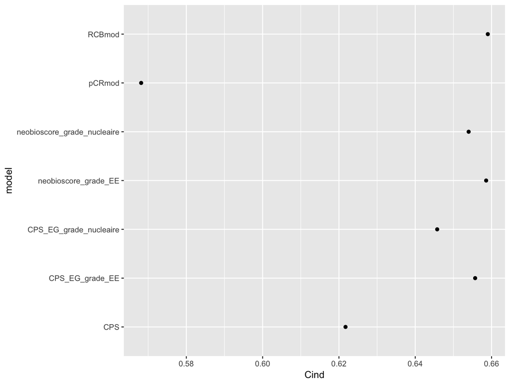

```r
ggplot(test, aes (x = model, y=Cind)) + geom_point()+ coord_flip()
```

# **Nest()**

Résume le tibble en une liste de data frame

```r
cur2 <- curie %>% nest(-groupe)
cur2
```

```
## # A tibble: 3 x 2
##       groupe                 data
##       <fctr>               <list>
## 1      her2+ <tibble [294 x 136]>
## 2 basal like <tibble [376 x 136]>
## 3    luminal <tibble [529 x 136]>
```

```r
cur2 <- curie %>%
  nest(-groupe) %>%
  mutate(model = map(data, ~glm(pcr ~ T_preop+Node_preop, data=., family = "binomial"))) %>%
  mutate (est = map(model, tidy))

cur2
```

```
## # A tibble: 3 x 4
##       groupe                 data     model                  est
##       <fctr>               <list>    <list>               <list>
## 1      her2+ <tibble [294 x 136]> <S3: glm> <data.frame [5 x 5]>
## 2 basal like <tibble [376 x 136]> <S3: glm> <data.frame [5 x 5]>
## 3    luminal <tibble [529 x 136]> <S3: glm> <data.frame [5 x 5]>
```

```r
cur2$est
```

```
## [[1]]
##            term   estimate std.error  statistic   p.value
## 1   (Intercept)  0.2897679 0.4944228  0.5860731 0.5578264
## 2      T_preop2 -0.7307590 0.4975789 -1.4686294 0.1419333
## 3    T_preop3/4 -0.7358222 0.5285081 -1.3922628 0.1638428
## 4   Node_preop1 -0.1576794 0.2500971 -0.6304725 0.5283855
## 5 Node_preop2/3  0.2326709 0.5900588  0.3943181 0.6933462
##
## [[2]]
##            term    estimate std.error  statistic     p.value
## 1   (Intercept)  0.56538248 0.4016518  1.4076435 0.159236662
## 2      T_preop2 -1.18527689 0.4002644 -2.9612347 0.003064083
## 3    T_preop3/4 -1.39028037 0.4332323 -3.2090878 0.001331568
## 4   Node_preop1  0.09927236 0.2237884  0.4435992 0.657332366
## 5 Node_preop2/3 -0.21498302 0.5030527 -0.4273568 0.669119453
##
## [[3]]
##            term   estimate std.error  statistic     p.value
## 1   (Intercept) -3.5215049 1.0890332 -3.2336066 0.001222377
## 2      T_preop2  0.6961972 1.0619017  0.6556136 0.512072764
## 3    T_preop3/4 -0.4067533 1.1385485 -0.3572560 0.720900190
## 4   Node_preop1  0.4462424 0.3965821  1.1252208 0.260495479
## 5 Node_preop2/3  2.0996982 0.6800605  3.0875169 0.002018363
```

```r
unnest(cur2, est)
```

```
## # A tibble: 15 x 6
##        groupe          term    estimate std.error  statistic     p.value
##        <fctr>         <chr>       <dbl>     <dbl>      <dbl>       <dbl>
##  1      her2+   (Intercept)  0.28976786 0.4944228  0.5860731 0.557826421
##  2      her2+      T_preop2 -0.73075902 0.4975789 -1.4686294 0.141933343
##  3      her2+    T_preop3/4 -0.73582224 0.5285081 -1.3922628 0.163842832
##  4      her2+   Node_preop1 -0.15767936 0.2500971 -0.6304725 0.528385501
##  5      her2+ Node_preop2/3  0.23267087 0.5900588  0.3943181 0.693346210
##  6 basal like   (Intercept)  0.56538248 0.4016518  1.4076435 0.159236662
##  7 basal like      T_preop2 -1.18527689 0.4002644 -2.9612347 0.003064083
##  8 basal like    T_preop3/4 -1.39028037 0.4332323 -3.2090878 0.001331568
##  9 basal like   Node_preop1  0.09927236 0.2237884  0.4435992 0.657332366
## 10 basal like Node_preop2/3 -0.21498302 0.5030527 -0.4273568 0.669119453
## 11    luminal   (Intercept) -3.52150490 1.0890332 -3.2336066 0.001222377
## 12    luminal      T_preop2  0.69619719 1.0619017  0.6556136 0.512072764
## 13    luminal    T_preop3/4 -0.40675326 1.1385485 -0.3572560 0.720900190
## 14    luminal   Node_preop1  0.44624241 0.3965821  1.1252208 0.260495479
## 15    luminal Node_preop2/3  2.09969819 0.6800605  3.0875169 0.002018363
```

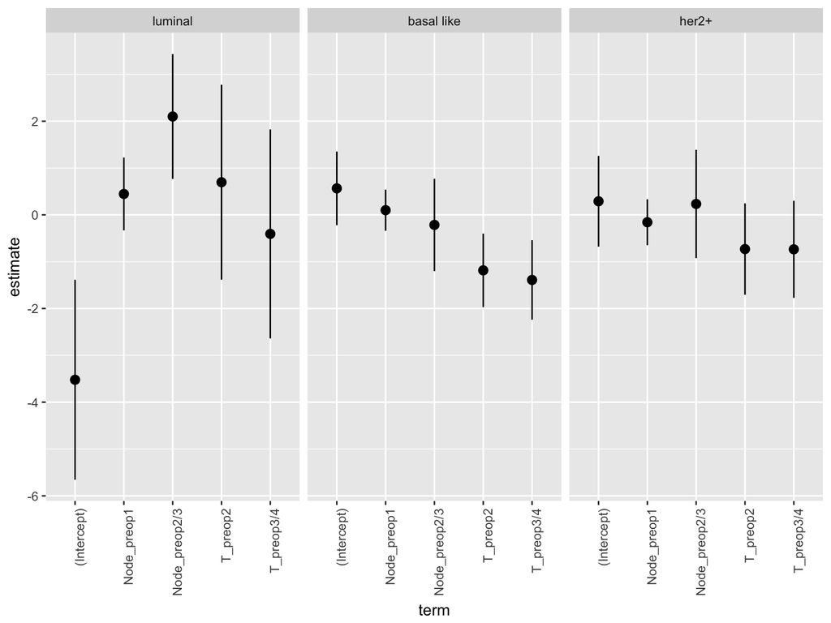

```r
unnest(cur2, est) %>% mutate (
  icbas = estimate-1.96*std.error,
  ichaut = estimate+1.96*std.error) %>%
  ggplot(aes(x=term, y=estimate, ymin = icbas, ymax= ichaut))+
  geom_pointrange() +
  facet_wrap(~groupe)+
  theme(axis.text.x = element_text(angle = 90, hjust = 1))
```